# Visualizing Starwars characters

Simon Taylor

2022-09-26

### Glimpse at the starwars data frame.

The `starwars` data set contains information about many different characters from the Star Wars films.

```r
glimpse(starwars)
```

```
## Rows: 87
## Columns: 14
## $ name       <chr> "Luke Skywalker", "C-3PO", "R2-D2", "Darth Vader", "Leia Or…
## $ height     <int> 172, 167, 96, 202, 150, 178, 165, 97, 183, 182, 188, 180, 2…
## $ mass       <dbl> 77.0, 75.0, 32.0, 136.0, 49.0, 120.0, 75.0, 32.0, 84.0, 77.…
## $ hair_color <chr> "blond", NA, NA, "none", "brown", "brown, grey", "brown", N…
## $ skin_color <chr> "fair", "gold", "white, blue", "white", "light", "light", "…
## $ eye_color  <chr> "blue", "yellow", "red", "yellow", "brown", "blue", "blue",…
## $ birth_year <dbl> 19.0, 112.0, 33.0, 41.9, 19.0, 52.0, 47.0, NA, 24.0, 57.0, …
## $ sex        <chr> "male", "none", "none", "male", "female", "male", "female",…
## $ gender     <chr> "masculine", "masculine", "masculine", "masculine", "femini…
## $ homeworld  <chr> "Tatooine", "Tatooine", "Naboo", "Tatooine", "Alderaan", "T…
## $ species    <chr> "Human", "Droid", "Droid", "Human", "Human", "Human", "Huma…
## $ films      <list> <"The Empire Strikes Back", "Revenge of the Sith", "Return…
## $ vehicles   <list> <"Snowspeeder", "Imperial Speeder Bike">, <>, <>, <>, "Imp…
## $ starships  <list> <"X-wing", "Imperial shuttle">, <>, <>, "TIE Advanced x1",…
```

We can see that the data set consists of 87 characters, with data collected across 14 different variables.

### 1. Create a data visualisation that shows the relationship between the height and the mass of the characters.

Both height and weight are numerical variables, so the best type of data visualisation to illustrate this relationship is a scatter plot. This can be created by adding a `geom_point()` layer.

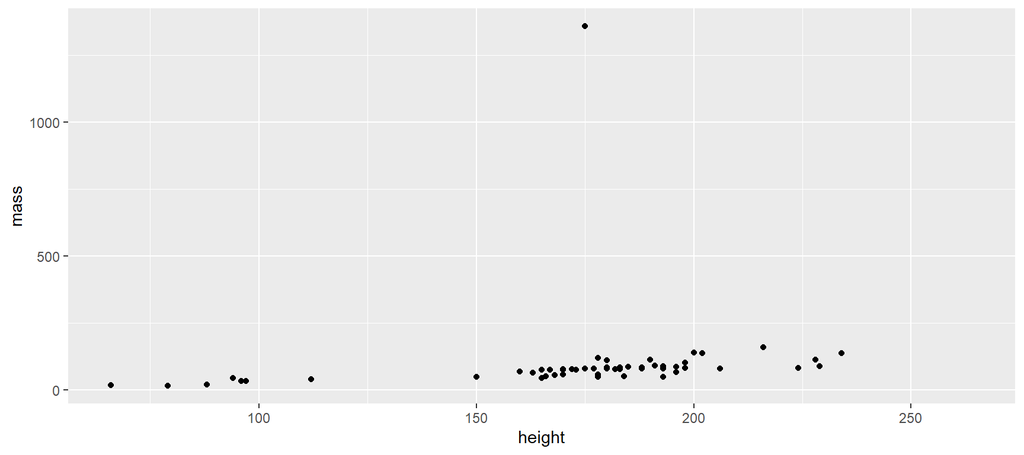

```r
ggplot(data = starwars,
       mapping = aes(x = height,
                     y = mass)) +
  geom_point()
```

What do you see in this data visualisation?

Do you notice the outlying point at around 175cm in height and 1300kg in mass, could this be an error in the data set? Let’s take a closer look at the data. On the console (not in your R Markdown document) type `view(starwars)` to see a spreadsheet of the data. (Note, you may need to run `library(tidyverse)` on the console first). Sort the `mass` variable in decreasing order. The character with the largest mass is `Jabba Desilijic Tiure`, or (Jabba the Hutt)[https://en.wikipedia.org/wiki/Jabba_the_Hutt], who is a large and heavy slug-like creature. So no, there does not appear to be an error in the data!

Let’s now zoom into the data visualisation to see the relationship between height and mass amongst the other characters.

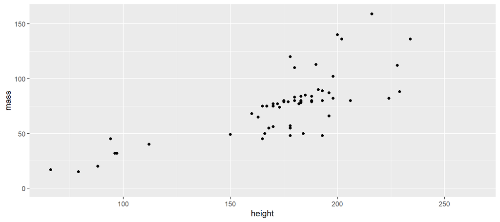

```r
ggplot(data = starwars,
       mapping = aes(x = height,
                     y = mass)) +
  geom_point() +
  coord_cartesian(y = c(0, 160))
```

How would you describe the relationship between the two variables?

### 2. Modify the scatter plot to change the colour of the points.

First, lets make all of the points blue…

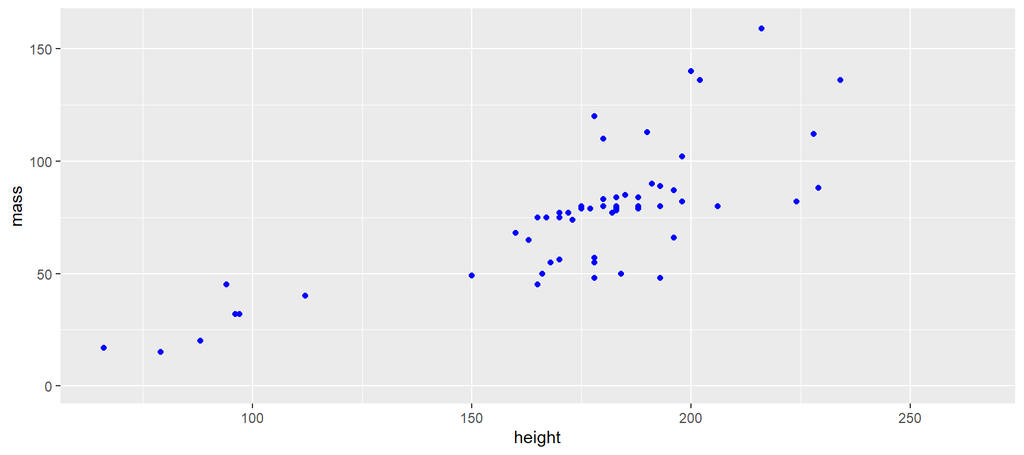

```r
ggplot(data = starwars,
       mapping = aes(x = height,
                     y = mass)) +
  geom_point(
    colour = "blue"
  ) +
  coord_cartesian(y = c(0, 160))
```

R has a long list of colours that you can call by name, some of the common colours are `"black"`, `"red"`, `"green"`, `"blue"`, `"yellow"`, `"magenta"`, `"cyan"` and `"grey"`. However it is difficult to find the name of the specific colour you want, so R also understands the hexadecimal coding for colours. For example, `#f36ddf` is the hexadecimal code for a nice shade of pink.

Go the the [Color codes website](https://htmlcolorcodes.com/color-picker/) and find a colour that you like and make this the colour of the points in the scatter plot.

We can use colour to examine how the relationship between character height and weight may vary depending on another variable. For this we instead define the colour in the `aes`thetics. For example, we can use colour to indicate the character’s gender.

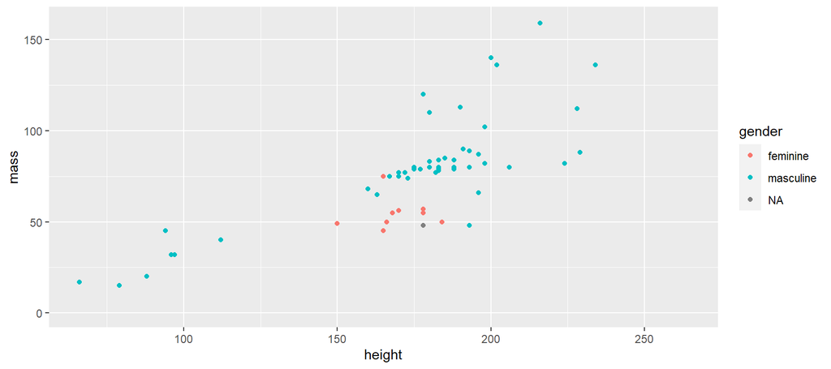

```r
ggplot(data = starwars,
       mapping = aes(x = height,
                     y = mass,
                     colour = gender)) +
  geom_point() +
  coord_cartesian(y = c(0, 160))
```

Change the above code so that points are coloured based on the character’s `species`. What is the problem with this data visualisation?

What happens to the data visualisation if you instead map character’s gender to `shape`?

What happens if you add `size = birth_year` into the aesthetics function?

What happens if you specify the colour in *both* the `aes()` function *and* the `geom_point()` function?

### 3. Add axis labels and a title

Remember that a data visualisation is just a pretty picture unless you know what the visualisation is about, so it is important to add axis labels and a title.

Edit the following code with a suitable title and axis labels.

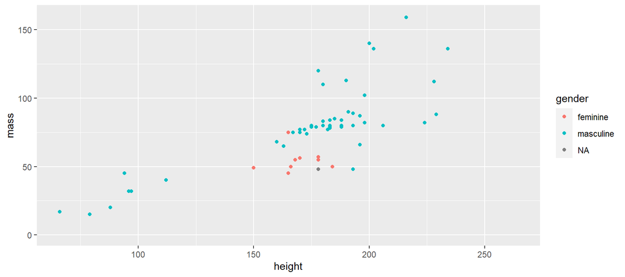

```r
ggplot(data = starwars,
       mapping = aes(x = height,
                     y = mass,
                     color = gender)) +
  geom_point() +
  coord_cartesian(y = c(0, 160)) +
  labs(
    #title = "___",
    #x = "___",
    #y = "___"
    )
```

We can even change the title of the colour legend. In the above code add `colour = "Gender"` into the `labs()` function.

### 4. Pick a single categorical variable and make a bar plot.

Now it is over to you to explore what other structures and relationships exist within the `starwars` data set.

(NOTE: A little bit of code is provided below to help you get started with the structure. However, this code is currently not proper R code and won’t run. As such, the code chunk is set to not e evaluated with `eval = FALSE`. Once you have written valid R code for your visualisation, set `eval = TRUE`, or remove this argument from the curly brackets, and knit your document.)

```r
ggplot(data = starwars,
       mapping = aes(___)) +
  geom___()
```

What features do you see in the visualisation, and what does it tell you about the variable you have selected?

### 5. Pick a single numerical variable and make a histogram.

(This time no starter code is provided, you’re on your own!)

```r
# write your code here!
```

What features do you see in the visualisation, and what does it tell you about the variable you have selected?

### 6. Pick a numerical variable and a categorical variable.

Make a visualisation to examine the relationship between two different types variables. You choose the style of the visualisation, whether that be a box plot, a violin plot, a bar chart or something different.

```r
# write your code here!
```

Interpret what your data visualisation says about the relationship (if there is one) between the numerical and categorical variable you have chosen?

### 7. Go wild!

Copy the code of one of the data visualisations above into the R code chunk below. Add as many different features to the visualisation that you can to make is as ugly and as incomprehensible as possible!

```r
# write your code here!
```